# ランダム化比較試験

Jaehyun Song

改訂: 2021-08-30

# パッケージとデータの読み込み

ここでは主に以下の3つのパッケージを使います。

- {tidyverse}: R界隈の神様、Hadley先生のパッケージ集。主に{dplyr}と{ggplot2}を使います。
- {coefplot}: 回帰分析の結果を見やすく可視化してくれるパッケージです。
- {BalanceR}: バランスチェックのパッケージです。GitHub経由でインストールする必要があり、後ほど解説します。

パッケージのインストールにはいくつかの方法があります。まず、Rの公式レポジトリであるCRANに登録されている{tidyverse}、{coefplot}は`install.packages()`を使います。

```r
# CRANに登録されているパッケージのインストール
# インストールは一回だけで十分
install.packages("tidyverse")
install.packages("coefplot")
install.packages("summarytools")
install.packages("DT")
install.packages("broom")
install.packages("stargazer")
install.packages("modelsummary")
```

また、CRANに登録されず、GitHubに登録されているパッケージは{devtools}パッケージ、または{remote}パッケージが提供している`install_github()`を使います。

```r
# JaehyunSongレポジトリのBalanceRをインストール
# パッケージ名::関数() だと、わざわざ{devtools}を読み込む必要はない
# remotes::install_github()もOK（事前に{remotes}パッケージをインストールしておくこと）
devtools::install_github("JaehyunSong/BalanceR")
```

他にもいくつかのパッケージを使用しますが、必須ではありません。

- {summarytools}: 記述統計を見やすく見せてくれます。なくてもOK
- {DT}: データフレーム（または、tibble）形式のデータを見やすく出力するパッケージです。R Markdownを使用しない場合は使わなくて結構です。
- {broom}: 推定結果をデータフレーム形式に要約する`tidy()`関数が含まれています。
- {purrr}: データフレームにおける行単位反復演算パッケージです。
  - {tidyverse}と同時に読み込まれます。
- {stargazer}: 回帰分析の推定値を表でまとめるパッケージです。
- {modelsummary}: {stargazer}の代替パッケージ

```r
# パッケージの読み込みはlibrary(パッケージ名)
# R再起動の度に読み込む必要がある
library(tidyverse)    # Thanks, Hadley!
library(summarytools) # データの記述統計
library(coefplot)     # 係数の可視化
library(DT)           # データフレームを見やすく
library(stargazer)    # 推定結果を表としてまとめるパッケージ (1)
library(modelsummary) # 推定結果を表としてまとめるパッケージ (2)
library(BalanceR)     # 実験データのバランスチェック
```

実は{pacman}があれば、もっと便利です。{pacman}の`p_load()`関数は`library()`同様、パッケージの読み込み関数ですが、インストールされていない場合、自動的にインストールまでしてくれます[^1]。また、`()`内に複数のパッケージを入れることも可能です。上記のコードだと以下のように書き換えることが可能です。ただし、事前に{pacman}パッケージをインストールしておく必要があります。

```r
# {pacman}のp_load()を使ってらくらくパッケージ読み込み
pacman::p_load(tidyverse, summarytools, coefplot, DT,
               stargazer, modelsummary, BalanceR)
```

それでは、`Day1_Data3.csv`を読み込み、`GG_df`と名付けて格納します。

```r
# dfはdata.frameの略です。データのパスは各自変更すること
# read_csv()の代わりにread.csv()もOK
GG_df <- read_csv("Data/Day1_Data3.csv")
```

データの詳細については[Gerber, Green, and Larimer (2008)](https://www.cambridge.org/core/journals/american-political-science-review/article/social-pressure-and-voter-turnout-evidence-from-a-largescale-field-experiment/11E84AF4C0B7FBD1D20C855972C2C3EB)を参照してください。まずはデータの大きさを確認します。

```r
dim(GG_df)
```

```
## [1] 344084      8
```

```r
print(GG_df, n = 20) # read_csv()で読み込んだ場合
```

```
## # A tibble: 344,084 x 8
##    sex      yob p2000 p2002 p2004 treatment  voted hh_size
##    <chr>  <dbl> <chr> <chr> <chr> <chr>      <chr>   <dbl>
##  1 male    1941 no    yes   No    Civic Duty No          2
##  2 female  1947 no    yes   No    Civic Duty No          2
##  3 male    1951 no    yes   No    Hawthorne  Yes         3
##  4 female  1950 no    yes   No    Hawthorne  Yes         3
##  5 female  1982 no    yes   No    Hawthorne  Yes         3
##  6 male    1981 no    no    No    Control    No          3
##  7 female  1959 no    yes   No    Control    Yes         3
##  8 male    1956 no    yes   No    Control    Yes         3
##  9 female  1968 no    yes   No    Control    No          2
## 10 male    1967 no    yes   No    Control    No          2
## 11 male    1941 no    no    Yes   Control    Yes         1
## 12 male    1945 no    no    No    Hawthorne  No          2
## 13 female  1949 no    yes   No    Hawthorne  Yes         2
## 14 female  1969 no    no    Yes   Control    No          1
## 15 female  1967 yes   yes   Yes   Control    Yes         2
## 16 male    1961 no    yes   Yes   Control    Yes         2
## 17 female  1957 no    no    No    Self       No          2
## 18 male    1955 no    no    No    Self       No          2
## 19 female  1943 no    yes   No    Control    Yes         1
## 20 male    1939 no    yes   No    Neighbors  Yes         1
## # … with 344,064 more rows
```

データ読み込みの際、`read_csv()`でなく、`read.csv()`を使った場合、以下のコードで最初の20行を出力できます（`n =`を指定しないと、既定値として6行まで出力されます）。

```r
head(GG_df, n = 20)  # read.csv()で読み込んだ場合
```

R Markdownを使用している場合、`DT::datatable()`関数を使用すると、より見やすい表として出力されます。ちなみに、`DT::datatable()`とは{DT}パッケージの`datatable()`関数を意味します。普段は`DT::`を略しても構いませんが、もし、複数のパッケージが同じ名前の関数を提供している場合は、このようにパッケージ名を明記します。今後、「{XX}パッケージの`YY`関数」を`XX:YY`と表記します。

```r
# GG_dfの1行から100行までを、datatable形式で出力
datatable(GG_df[1:100, ])
```

|  | sex | yob | p2000 | p2002 | p2004 | treatment | voted | hh_size |
| --- | --- | --- | --- | --- | --- | --- | --- | --- |
| 1 | male | 1941 | no | yes | No | Civic Duty | No | 2 |
| 2 | female | 1947 | no | yes | No | Civic Duty | No | 2 |
| 3 | male | 1951 | no | yes | No | Hawthorne | Yes | 3 |
| 4 | female | 1950 | no | yes | No | Hawthorne | Yes | 3 |
| 5 | female | 1982 | no | yes | No | Hawthorne | Yes | 3 |
| 6 | male | 1981 | no | no | No | Control | No | 3 |
| 7 | female | 1959 | no | yes | No | Control | Yes | 3 |
| 8 | male | 1956 | no | yes | No | Control | Yes | 3 |
| 9 | female | 1968 | no | yes | No | Control | No | 2 |
| 10 | male | 1967 | no | yes | No | Control | No | 2 |

[output cut: 90 more lines]

実は変数が約10個を超えてしまうと、大画面のモニターじゃない限り、かなり見づらいです。ここでは、「分析のためのデータとはどのような構造をしているのか」を確認するだけで十分です。

# 記述統計を見る

データフレーム全体の記述統計 (平均値、頻度など)を見る簡単な方法は`summary(データフレーム名)`です。

```r
summary(GG_df)
```

```
##      sex                 yob          p2000              p2002
##  Length:344084      Min.   :1900   Length:344084      Length:344084
##  Class :character   1st Qu.:1947   Class :character   Class :character
##  Mode  :character   Median :1956   Mode  :character   Mode  :character
##                     Mean   :1956
##                     3rd Qu.:1965
##                     Max.   :1986
##     p2004            treatment            voted              hh_size
##  Length:344084      Length:344084      Length:344084      Min.   :1.000
##  Class :character   Class :character   Class :character   1st Qu.:2.000
##  Mode  :character   Mode  :character   Mode  :character   Median :2.000
##                                                           Mean   :2.184
##                                                           3rd Qu.:2.000
##                                                           Max.   :8.000
```

記述統計をもっと見やすく見せてくれる関数として{summarytools}が提供する`dfSummary()`があります。R Markdownに埋め込む場合以下のようなコマンドを打ち込みますが、Rコンソール上では`view(dfSummary(GG_df))`と打ち込みます (もっと見やすい)。

```r
# 以下のコードはR Markdwonを使用する際に使う
print(dfSummary(GG_df, style = "grid",
                plain.ascii = FALSE, graph.magnif = 0.85),
      method = "render", headings = FALSE)
```

| **No** | **Variable** | **Stats / Values** | **Freqs (% of Valid)** | **Graph** | **Valid** | **Missing** |
| --- | --- | --- | --- | --- | --- | --- |
| 1 | sex [character] | 1. female 2. male | 171795 ( 49.9% ) 172289 ( 50.1% ) |  | 344084 (100.0%) | 0 (0.0%) |
| 2 | yob [numeric] | Mean (sd) : 1956.2 (14.4) min ≤ med ≤ max: 1900 ≤ 1956 ≤ 1986 IQR (CV) : 18 (0) | 86 distinct values |  | 344084 (100.0%) | 0 (0.0%) |
| 3 | p2000 [character] | 1. no 2. yes | 257464 ( 74.8% ) 86620 ( 25.2% ) |  | 344084 (100.0%) | 0 (0.0%) |
| 4 | p2002 [character] | 1. no 2. yes | 209947 ( 61.0% ) 134137 ( 39.0% ) |  | 344084 (100.0%) | 0 (0.0%) |
| 5 | p2004 [character] | 1. No 2. Yes | 205934 ( 59.8% ) 138150 ( 40.2% ) |  | 344084 (100.0%) | 0 (0.0%) |
| 6 | treatment [character] | 1. Civic Duty 2. Control 3. Hawthorne 4. Neighbors 5. Self | 38218 ( 11.1% ) 191243 ( 55.6% ) 38204 ( 11.1% ) 38201 ( 11.1% ) 38218 ( 11.1% ) |  | 344084 (100.0%) | 0 (0.0%) |
| 7 | voted [character] | 1. No 2. Yes | 235388 ( 68.4% ) 108696 ( 31.6% ) |  | 344084 (100.0%) | 0 (0.0%) |
| 8 | hh_size [numeric] | Mean (sd) : 2.2 (0.8) min ≤ med ≤ max: 1 ≤ 2 ≤ 8 IQR (CV) : 0 (0.4) | 1 : 47834 ( 13.9% ) 2 : 214086 ( 62.2% ) 3 : 57474 ( 16.7% ) 4 : 20916 ( 6.1% ) 5 : 3315 ( 1.0% ) 6 : 402 ( 0.1% ) 7 : 49 ( 0.0% ) 8 : 8 ( 0.0% ) |  | 344084 (100.0%) | 0 (0.0%) |

Generated by summarytools 1.0.0 ([R](https://www.r-project.org/) version 4.1.1)  
2021-08-30

# データのクリーニング

## 変数のダミー化

まずは、性別と投票有無をダミー変数にします。たとえば、性別を表す`sex`変数は`"male"`と`"female"`といった2つの値で構成されます。パソコンにとっては文字列よりは数字の方が都合が良いので、これらの値を数値化します。

具体的には、`Female`という変数を作成し、もし`sex`が`"female"`なら`1`を、それ以外なら`0`を入れます。新しい変数（列）を追加したり、既存の列を上書きする際は{dplyr}パッケージの`mutate()`関数を、条件による値の割り当てには{dplyr}パッケージの`if_else()`関数を使います[^2]。`if_else()`関数は`if_else(条件, 条件が満たされる場合, それ以外の場合)`です。

`mutate()`と`if_else()`関数の使い方は以下の通りです。

```r
# if_else()の代わりにifelse()もOK
データフレーム名1 <- データフレーム名2 %>%
  mutate(新しい変数名 = if_else(条件式, 条件がTRUEの場合, 条件がFALSEの場合))
```

ここで登場する`%>%`はパイプ（pipe）演算子と呼ばれるもので、「今どきのR」では欠かせない演算子となります。これはパイプの前にあるオブジェクトをパイプ後にある関数の第一引数として渡すことを意味します。詳細は[宋・矢内資料](https://www.jaysong.net/RBook/datahandling1.html#handling1-pipe)を参照してください。

`データフレーム名1`と`データフレーム名2`が同じなら、上書きとなります。別の名前なら`データフレーム名1`という新しいデータオブジェクトが生成されます。`mutate()`は新しい列を作成する関数です。たとえば`muate()`の中身が`Female = if_else(sex == "female", 1, 0)`なら、`Female`という新しい列を作成し、その列の中身は`if_else()`の処理結果となります。

`if_else()`の条件式は`sex`の値が`"female"`か否かを判定します。そして判定結果がTRUE（真）なら1を、FALSE（偽）0を返します。条件式において「同値」は`=`でなく、`==`であることに注意してください。また、`"female"`は`"`で囲みますが、`0`と`1`は囲みません。文字型、factor型オブジェクトの値は`"`で囲みますが、数値型は`"`を使いません。`"0"`にすると、数値型でなく文字型として値を返します。

2000年、2002年、2004年、2006年に投票したか否かを表す変数も同様に処理します。

```r
# dplyrを使う場合
GG_df <- GG_df %>%
    mutate(Female = if_else(sex   == "female", 1, 0),
           V2000  = if_else(p2000 == "yes",    1, 0),
           V2002  = if_else(p2002 == "yes",    1, 0),
           V2004  = if_else(p2004 == "Yes",    1, 0),
           Voted  = if_else(voted == "Yes",    1, 0))
```

```r
# dplyrを使わない場合
GG_df$Female <- ifelse(GG_df$sex == "female", 1, 0)
GG_df$V2000  <- ifelse(GG_df$p2000 == "yes",  1, 0)
GG_df$V2002  <- ifelse(GG_df$p2002 == "yes",  1, 0)
GG_df$V2004  <- ifelse(GG_df$p2004 == "yes",  1, 0)
GG_df$Voted  <- ifelse(GG_df$voted == "yes",  1, 0)
```

## 処置変数のfactor化

ここはしてもしなくても問題ありませんが、プロットなどで順番を自分で決めたい場合は、文字型をfactor型に変換した方が便利です。factor型の詳細は[宋・矢内資料](https://www.jaysong.net/RBook/factor.html)を参照してください。ちなみに文字型のままだと、順番はアルファベット順になります。やはり統制群を一番最初か最後に置きたいので、今回は`levels = c(...)`を指定して、要素に順番を付けましょう。

新しい処置変数として`Treat`という変数を作成します。これは既存の`treatment`変数を`factor()`関数を使ってfactor型に変換した変数です。そして、値の順番を`levels = ...`引数で指定します。`GG_df`の`treatment`変数がどのような値で構成されているかを確認するためには`unique()`関数を使います。

```r
# ベクトルを構成する要素を出力
unique(GG_df$treatment)
```

```
## [1] "Civic Duty" "Hawthorne"  "Control"    "Self"       "Neighbors"
```

`treatment`列は`"Civic Duty"`、`"Control"`、`"Hawthorne"`、`"Neighbors"`、`"Self"`の値のみで構成されています。そして、これらの値の順番を付けたいとします。その順番を`levels =`引数の実引数[^3]として指定します。今回は統制群、Civic Duty群、Hawthorne群、Self群、Neighbors群の順番にしましょう。

```r
# dplyrを使う場合
GG_df <- GG_df %>%
    mutate(Treat = factor(treatment,
                          levels = c("Control", "Civic Duty",
                                     "Hawthorne", "Self", "Neighbors")))
```

`GG_df`に新しく生成された`Treat`列のデータ型を`class()`型で確認します。

```r
class(GG_df$Treat)
```

```
## [1] "factor"
```

factor型になっていますね。また、ちゃんと順番付になっているかを`levels()`関数を使って確認します。

```r
levels(GG_df$Treat)
```

```
## [1] "Control"    "Civic Duty" "Hawthorne"  "Self"       "Neighbors"
```

先ほど指定した順番でfactorの水準が並んでいることが分かります。

# バランスチェック

## 簡単な方法

それでは、無作為割当が成功しているかを確認するためにバランスチェックをしてみましょう。まずは、単純に平均値を比較ししてみましょう。たとえば、誕生年（`yob`）にグループごとの差があるかを確認したいとします。この場合、（１）実験群ごとに（２）`yob`の平均値を計算する必要があります。グループごとに計算を行うにはデータを`group_by()`変数を使ってグループ化します。そして、ある変数の記述統計量を計算するには`summarise()`関数を使います。どれも{dplyr}パッケージの関数です。たとえば、`Treat`の値でグループ化し、`yob`の平均値を計算した結果を`YearOfBirth`という列として出力するとします。`group_by()`にはグループ化の基準となる変数を指定します。`summarise()`関数の中身は`出力される列名 = 関数(引数)`となります。

```r
GG_df %>%
  group_by(Treat) %>%
  summarise(YearOfBirth = mean(yob),
            .groups     = "drop")
```

```
## # A tibble: 5 × 2
##   Treat      YearOfBirth
##   <fct>            <dbl>
## 1 Control          1956.
## 2 Civic Duty       1956.
## 3 Hawthorne        1956.
## 4 Self             1956.
## 5 Neighbors        1956.
```

各グループごとに`yob`変数の平均値が計算され、その結果が`YearOfBirth`列として出力されます。`.groups`引数は無視しても構いませんが、dplyr 1.0.0以降では明示することが推奨されています。`.groups`引数の詳細は[宋・矢内の参考資料](https://www.jaysong.net/RBook/datahandling2.html#handling2-group)を参照してください。

これらの作業を女性（`Female`）、世帯人数（`hh_size`）、誕生年（`yob`）、2000年から2004年からの投票有無（`V2000`、`V2002`、`V2004`）に対して行います。

```r
GG_df %>% # GG_dfを
    group_by(Treat) %>% # Treat変数でグループ化し、
    summarise(Female  = mean(Female), # これらの変数の平均値
              HH_Size = mean(hh_size),# を表示させましょう。
              YOB     = mean(yob),
              V2000   = mean(V2000),
              V2002   = mean(V2002),
              V2004   = mean(V2004),
              .groups = "drop")       # dplyr 1.0.0以降では指定する必要あり
```

```
## # A tibble: 5 × 7
##   Treat      Female HH_Size   YOB V2000 V2002 V2004
##   <fct>       <dbl>   <dbl> <dbl> <dbl> <dbl> <dbl>
## 1 Control     0.499    2.18 1956. 0.252 0.389 0.400
## 2 Civic Duty  0.500    2.19 1956. 0.254 0.389 0.399
## 3 Hawthorne   0.499    2.18 1956. 0.250 0.394 0.403
## 4 Self        0.500    2.18 1956. 0.251 0.392 0.402
## 5 Neighbors   0.500    2.19 1956. 0.251 0.387 0.407
```

グループは5つあり、それぞれ女性率、世帯人数、誕生年、2000・2002・2004年投票の投票有無はほぼ同じです。つまり、バランスは取れていると考えられます。

また、`n()`関数を使うと、各グループのサンプルサイズも計算されるため便利です。

```r
GG_df %>%
    group_by(Treat) %>%
    summarise(Female  = mean(Female),
              HH_Size = mean(hh_size),
              YOB     = mean(yob),
              V2000   = mean(V2000),
              V2002   = mean(V2002),
              V2004   = mean(V2004),
              N       = n(), # 各グループごとのサンプルサイズを出力する
              .groups = "drop")
```

```
## # A tibble: 5 × 8
##   Treat      Female HH_Size   YOB V2000 V2002 V2004      N
##   <fct>       <dbl>   <dbl> <dbl> <dbl> <dbl> <dbl>  <int>
## 1 Control     0.499    2.18 1956. 0.252 0.389 0.400 191243
## 2 Civic Duty  0.500    2.19 1956. 0.254 0.389 0.399  38218
## 3 Hawthorne   0.499    2.18 1956. 0.250 0.394 0.403  38204
## 4 Self        0.500    2.18 1956. 0.251 0.392 0.402  38218
## 5 Neighbors   0.500    2.19 1956. 0.251 0.387 0.407  38201
```

ちなみに以上のコードは`across()`関数を使えば、以下のように簡略化することができます（出力される変数名は上記の例と異なります）。`across()`関数は第一引数として指定された変数（列）に対し、第二引数と引数として指定された関数を実行します。ここで重要なのは第一引数として複数の変数を指定することができるという点です。複数の変数は`c()`でまとめることも出来ますし、`:`を使った隣接した列の抽出、`starts_with("V")`（Vで始まるすべての変数）、`ends_with("X")`（Xで終わるすべての変数）、`where(is.numeric)`（numeric型の全変数）など、{tidyselect}が提供する変数選択方式も使うことが出来ます。ここでは`Female`、`hh_size`、`yob`、`V2000`から`V2004`変数に対して`mean()`関数を実行します。`across()`内で関数名を実行するときは`()`は不要です[^4]。もし、欠損値を除外したい場合、第三引数として`na.rm = TRUE`を追加します。今回の`GG_df`には欠損値が含まれていないため、`mean`のみで十分です。

```r
GG_df %>%
  group_by(Treat) %>%
  summarise(across(c(Female, hh_size, yob, V2000:V2004), mean))
```

```
## # A tibble: 5 × 7
##   Treat      Female hh_size   yob V2000 V2002 V2004
##   <fct>       <dbl>   <dbl> <dbl> <dbl> <dbl> <dbl>
## 1 Control     0.499    2.18 1956. 0.252 0.389 0.400
## 2 Civic Duty  0.500    2.19 1956. 0.254 0.389 0.399
## 3 Hawthorne   0.499    2.18 1956. 0.250 0.394 0.403
## 4 Self        0.500    2.18 1956. 0.251 0.392 0.402
## 5 Neighbors   0.500    2.19 1956. 0.251 0.387 0.407
```

`mean()`以外にも標準偏差を出したい場合は`sd()`を使いますが、この2つを同時に使用する時には注意が必要です。それは列名が重複するという点です。上記のコードだと、`Female`の平均値は`Female`という名の列として出力されます。もし、以下のように`across()`を同じ変数に対して2回行うと、列名が重複してしまい、結果が正しく出力されません。

```r
GG_df %>%
  group_by(Treat) %>%
  summarise(across(c(Female, hh_size), mean),
            across(c(Female, hh_size), sd))
```

```
## # A tibble: 5 × 3
##   Treat      Female hh_size
##   <fct>       <dbl>   <dbl>
## 1 Control        NA      NA
## 2 Civic Duty     NA      NA
## 3 Hawthorne      NA      NA
## 4 Self           NA      NA
## 5 Neighbors      NA      NA
```

これを回避するためには`across()`内に`.names`引数を指定することで解決できます。たとえば、`.names`を`"Mean_{.col}"`にすると、`{.col}`の箇所に元の変数名が入ることになります。これは例を見た方が早いかも知れませんね。

```r
GG_df %>%
  group_by(Treat) %>%
  summarise(across(c(Female, hh_size), mean, .names = "Mean_{.col}"),
            across(c(Female, hh_size), sd, .names = "SD_{.col}"))
```

```
## # A tibble: 5 × 5
##   Treat      Mean_Female Mean_hh_size SD_Female SD_hh_size
##   <fct>            <dbl>        <dbl>     <dbl>      <dbl>
## 1 Control          0.499         2.18     0.500      0.788
## 2 Civic Duty       0.500         2.19     0.500      0.802
## 3 Hawthorne        0.499         2.18     0.500      0.789
## 4 Self             0.500         2.18     0.500      0.782
## 5 Neighbors        0.500         2.19     0.500      0.805
```

また、`across()`一つで2つ以上の関数を適用することもできます。第二引数に関数名を入れる際、複数の関数名を`list()`を使ってリスト型として指定し、`.names`においては関数名が入る箇所として`{.fn}`を追加するだけです（以下の例のように日本語のようなマルチバイト文字が含まれると出力される結果の列がずれることがありますので、なるべくローマ字を使いましょう）。

```r
GG_df %>%
  group_by(Treat) %>%
  summarise(across(c(女性 = Female, 世帯人数 = hh_size),
                   list(平均値 = mean, 標準偏差 = sd),
                   .names = "{.col}の{.fn}"))
```

```
## # A tibble: 5 × 5
##   Treat      女性の平均値 女性の標準偏差 世帯人数の平均値 世帯人数の標準偏差
##   <fct>             <dbl>          <dbl>            <dbl>              <dbl>
## 1 Control           0.499          0.500             2.18              0.788
## 2 Civic Duty        0.500          0.500             2.19              0.802
## 3 Hawthorne         0.499          0.500             2.18              0.789
## 4 Self              0.500          0.500             2.18              0.782
## 5 Neighbors         0.500          0.500             2.19              0.805
```

`across()`を使いこなせるようになれば、コードを数分の一までに減らすことができます。詳細な説明は[『私たちのR』の第14章](https://www.jaysong.net/RBook/datahandling2.html#handling2-summarise)を参照してください。

## パッケージを利用する

標準化バイアス/標準化差分 (Standardized Bias / Standardized Differenece; 以下、SB)を用いたバランスチェックをやってみましょう。SBは以下のように計算可能であり、あまり難しくありません。

$$\text{SB} = 100 \times \frac{\bar{X}_{\text{Treat}}-\bar{X}_{\text{Control}}}{\sqrt{\frac{1}{2}\cdot(s^2_{\text{Treat}} + s^2_{\text{Control}})}},$$

です[^5]。ここで$\bar{X}$は処置前変数の平均値であり、$s^2$は処置前変数の分散である。これが一定数値未満であればバランスが成立していると判断します。この基準はまた恣意的ではありますが、よく用いられる基準としては**絶対値**基準で3か5 (Caliendo and Kopeing, 2008)[^6]や、10 (Normand et al., 2001[^7]; Austine and Mamdani, 2005[^8])、25[^9]があります。

これらの作業は自分でやってもいいですが、パッケージが用意されているので積極的に使いましょう。{[cobalt](https://cran.r-project.org/web/packages/cobalt/vignettes/cobalt_A0_basic_use.html)}という素晴らしいパッケージもあり、様々な機能が搭載されていますが、ここではもっと簡単に使える{BalanceR}パッケージを使ってみましょう。[誰が作ったかは分かりませんが](https://www.jaysong.net)、非常に使いやすいパッケージです。

{BalanceR}パッケージはCRANではなく、[GitHub](https://github.com/)経由で配布されていますので、`devtools::install_github()`関数を使います。{devtools}パッケージがない場合は、先に{devtools}からインストールしておきましょう。最近はCRANでなく、GitHub経由でパッケージを公開する開発者も多いので、入れておいては損はありません。

```r
install.packages("devtools") # "remotes"パッケージでもOK

# remotes::install_github("JaehyunSong/BalanceR")もOK
devtools::install_github("JaehyunSong/BalanceR")
```

それではパッケージを読み込みます。

```r
library(BalanceR)
```

パッケージの使い方は{BalanceR}パッケージのホームページに譲ります。ここでは簡単な使い方のみ解説します。`BalanceR()`関数は`data`、`group`、`cov`の3つの引数のみを必要とします。`data`はデータフレーム名、`group`は実験群を示す変数名、`cov`はバランスをチェックする共変量の変数名です。共変量の指定は{dplyr}パッケージの`select()`関数と同じやり方で結構です[^10]。

```r
GG_Blc <- GG_df %>%
  BalanceR(group = Treat,
           cov = c(Female,
                   Household_Size = hh_size,
                   Year_of_Brith  = yob,
                   Voted2000      = V2000,
                   Voted2002      = V2002,
                   Voted2004      = V2004))
```

それでは結果を確認してみましょう。

```r
print(GG_Blc)
```

```
##        Covariate Mean:Control SD:Control Mean:Civic Duty SD:Civic Duty
## 1         Female        0.499      0.500           0.500         0.500
## 2 Household_Size        2.184      0.788           2.189         0.802
## 3  Year_of_Brith     1956.186     14.436        1956.341        14.465
## 4      Voted2000        0.252      0.434           0.254         0.435
## 5      Voted2002        0.389      0.488           0.389         0.487
## 6      Voted2004        0.400      0.490           0.399         0.490
##   Mean:Hawthorne SD:Hawthorne Mean:Self SD:Self Mean:Neighbors SD:Neighbors
## 1          0.499        0.500     0.500   0.500          0.500        0.500
## 2          2.180        0.789     2.181   0.782          2.188        0.805
## 3       1956.295       14.400  1956.207  14.416       1956.147       14.579
## 4          0.250        0.433     0.251   0.434          0.251        0.434
## 5          0.394        0.489     0.392   0.488          0.387        0.487
## 6          0.403        0.491     0.402   0.490          0.407        0.491
##   SB:Control-Civic Duty SB:Control-Hawthorne SB:Control-Self
```

[output cut: 27 more lines]

かなり長い表が表示されます。実験群が5つもあり、それぞれのペアごとにSBが計算されるため、10個の組み合わせが表示されるからです。

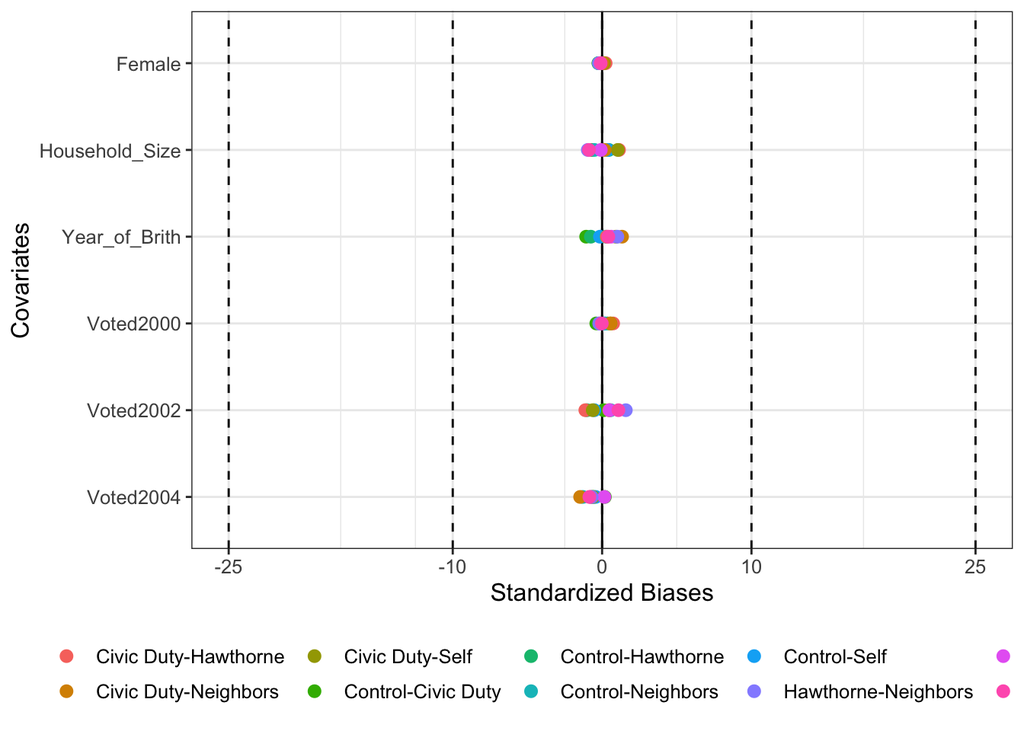

```r
# GG.Blcの可視化 (-25, -10, 10, 25に垂直線を引く)
plot(GG_Blc, vline = c(10, 25))
```

下の凡例が微妙なので、右側に移動させます。

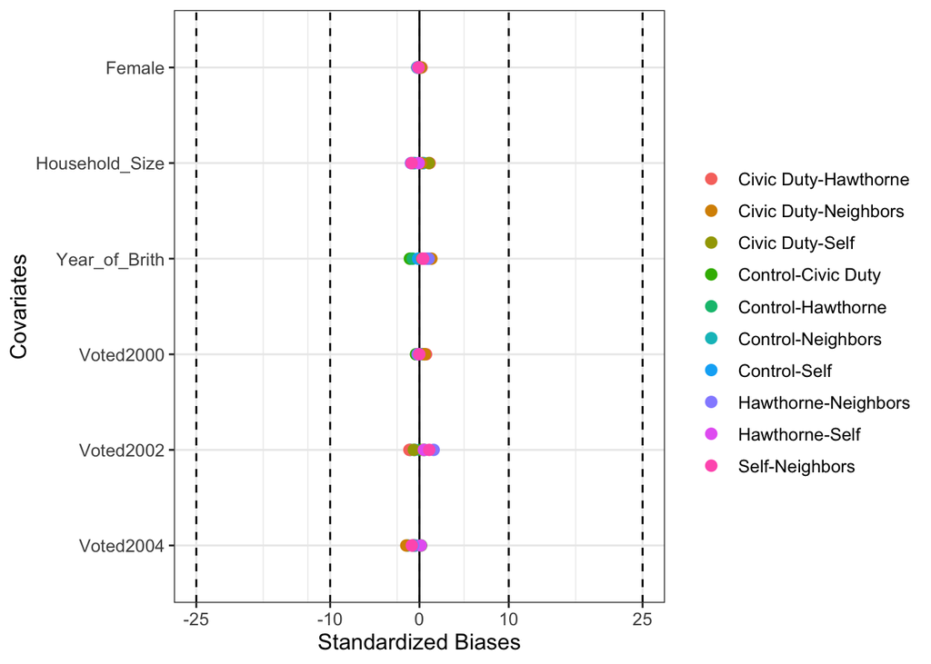

```r
plot(GG_Blc) +
  theme(legend.position = "right")
```

他にも`abs`と`simplify`引数を`TRUE`と指定することで、見やすくすることも可能です（既定値は両方`FALSE`）。今回は10ペアで標準化バイアスを計算しましたが、大事なのはこの標準化バイアスの最大値でしょう。また、標準化バイアスを絶対値に変換すると更に見やすくなります。

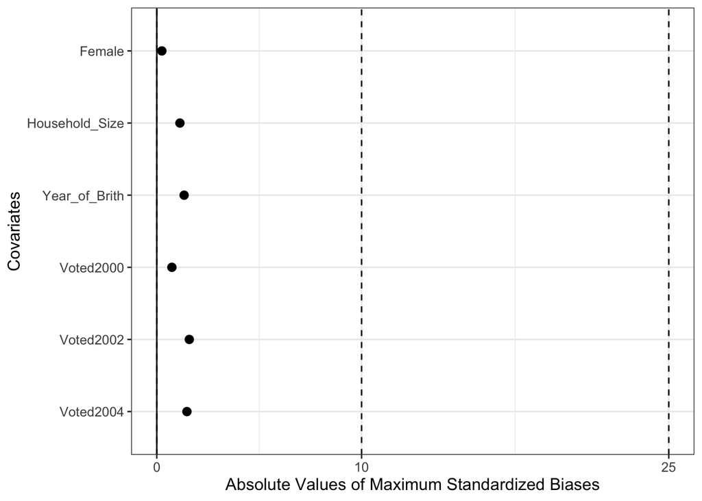

```r
plot(GG_Blc, abs = TRUE, simplify = TRUE)
```

だいぶ見やすくなりましたね。これを見ると、SBが極めて小さく、どのペアでも絶対値が非常に小さいのが分かります。これだとバランスが取れていると判断できるでしょう。

# 処置効果の推定

## まずは、グラフから

グラフを作るをする前にまず、作図に必要なデータを用意しておく必要があります。ここではそれぞれのグループごとの投票率を棒グラフとして出力します。そのために最低限に必要な情報は棒の横軸上の位置（`x`）と高さ（`y`）です。

それでは`group_by()`と`summarise()`を組み合わせて、`Treat`変数 (処置変数)ごとに`Voted`変数 (応答変数)の平均値がいくらかを計算してみましょう。

```r
GG_df2 <- GG_df %>%                # GG_dfを使って
  group_by(Treat) %>%              # Treatでグループ化し、
  summarise(Voted   = mean(Voted), # Voted変数の平均値を計算
            .groups = "drop")      # グループ化の解除 (dplyr 1.0.0以降)

GG_df2
```

```
## # A tibble: 5 × 2
##   Treat      Voted
##   <fct>      <dbl>
## 1 Control    0.297
## 2 Civic Duty 0.315
## 3 Hawthorne  0.322
## 4 Self       0.345
## 5 Neighbors  0.378
```

これを見ると、統制群の投票参加率が最も低く、`Neighbors`処置を受けた人の参加率が最も高いことが分かります。表でも問題ありませんが、これも可視化してみましょう。

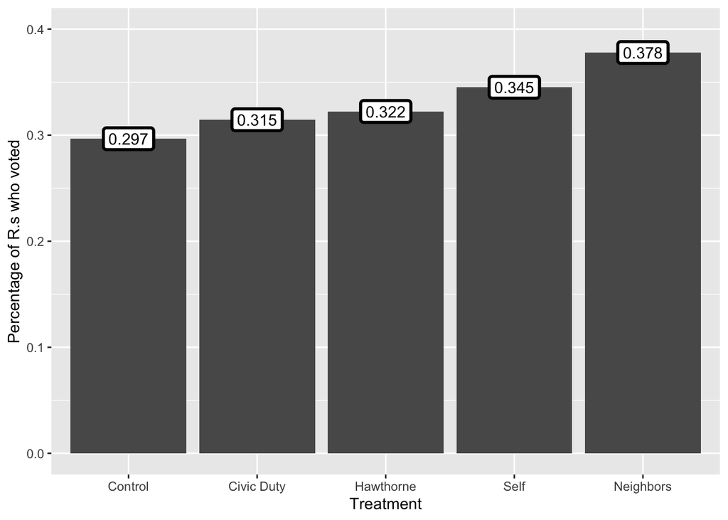

```r
GG_df2 %>%
  ggplot() +
  # x軸はTreat, y軸はVotedの平均値
  geom_bar(aes(x = Treat, y = Voted), stat = "identity") +
  # 棒に数値も付ける
  geom_label(aes(x = Treat, y = Voted,
                 label = round(Voted, 3)), label.size = 1) +
  # 軸ラベル
  labs(x = "Treatment", y = "Percentage of R.s who voted") +
  # y軸の最小値は0, 最大値は0.4にする
  coord_cartesian(ylim = c(0, 0.4))
```

ただし、以上のグラフは処置効果を表すものではありません。処置効果は「処置群における応答変数の期待値（平均値）」から「統制群における応答変数の期待値（平均値）」を引いたものだからです。したがって、処置効果を示すためには“処置群に比べてどれほど高いか/低いか”を表す棒グラフを作る必要があります。。これは単純に全ての値から統制群の平均値を引くだけでOKです。処置群の平均値から統制群の平均値を引いたものが**平均処置効果**です。

```r
# まずは、処置群の平均値を計算し、CtrlMeanに格納
# GG_dfのTreat列の値が"Control"であるVoted列を抽出し、平均値を計算
CtrlMean <- mean(GG_df$Voted[GG_df$Treat == "Control"])

CtrlMean
```

```
## [1] 0.2966383
```

後は`GG_df2`の`Voted`列から先ほど格納しました`CtrlMean`を引くだけです。こうすると統制群の行における`Voted`は0となり、グラフとして出力する意味がないため、`Treat`列の値が`"Control"`である行を除外します。ここで使うのが`filter()`関数です。引数としては条件式を入れますが、条件を**満たす**行のみが残ります。今回は「`Treat`の値が`"Control"`で**ない**」行を残します。Rにおける等号否定は`!=`を使います。Excelユーザーなら、`<>`に慣れているかも知れませんが、Rにおいて否定は`!`で表し、統合の否定は`!=`となります。

```r
GG_df3 <- GG_df2 %>%
  # Voted列の数値からCtrlMeanを引いた値をATEという新しい列に保存
  mutate(ATE = Voted - CtrlMean) %>%
  # GG_df2から処置群は除外します。どうせ0なんで
  filter(Treat != "Control")

GG_df3
```

```
## # A tibble: 4 × 3
##   Treat      Voted    ATE
##   <fct>      <dbl>  <dbl>
## 1 Civic Duty 0.315 0.0179
## 2 Hawthorne  0.322 0.0257
## 3 Self       0.345 0.0485
## 4 Neighbors  0.378 0.0813
```

それでは、作図をしてみましょう。作り方は先ほどと同じです。

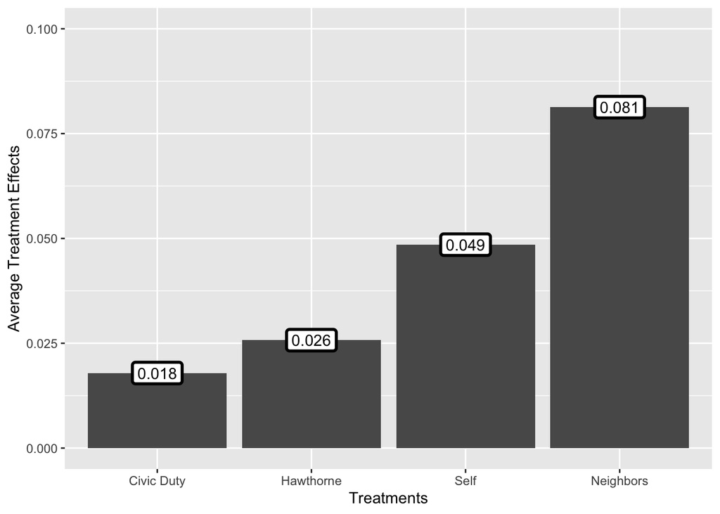

```r
GG_df3 %>%
    ggplot() +
    geom_bar(aes(x = Treat, y = ATE), stat = "identity") +
    geom_label(aes(x = Treat, y = ATE,
                   label = round(ATE, 3)), label.size = 1) +
    labs(x = "Treatments", y = "Average Treatment Effects") +
    coord_cartesian(ylim = c(0, 0.1))
```

また、よく見るのが、棒グラフにエラーバーを付けたものです。エラーバーの区間は信頼区間を意味します。ある変数の信頼区間を算出する手っ取り早い方法は一変数の*t*検定です。*t*検定は二群間比較以外の場合、つまり一群の平均値が0か否かを検定する場合にも使えます。この場合、ある変数の平均値が0であるという帰無仮説を検定することになります。同時にその変数の95%信頼区間も計算してくれるので便利です。信頼区間は`t検定オブジェクト名$conf.int`で95%信頼区間の下限（`[1]`）と上限（`[2]`）を抽出できます。何かの関数（今回は`t.test()`）から得られたオブジェクトの構造は`str(オブジェクト名)`で確認できます。

```r
# GG_dfのtreatmentが"Control"であるケースに絞ってVotedのt検定
Ctrl_t   <- t.test(GG_df$Voted[GG_df$treatment == "Control"])
str(Ctrl_t)
```

```
## List of 10
##  $ statistic  : Named num 284
##   ..- attr(*, "names")= chr "t"
##  $ parameter  : Named num 191242
##   ..- attr(*, "names")= chr "df"
##  $ p.value    : num 0
##  $ conf.int   : num [1:2] 0.295 0.299
##   ..- attr(*, "conf.level")= num 0.95
##  $ estimate   : Named num 0.297
##   ..- attr(*, "names")= chr "mean of x"
##  $ null.value : Named num 0
##   ..- attr(*, "names")= chr "mean"
##  $ stderr     : num 0.00104
##  $ alternative: chr "two.sided"
##  $ method     : chr "One Sample t-test"
##  $ data.name  : chr "GG_df$Voted[GG_df$treatment == \"Control\"]"
##  - attr(*, "class")= chr "htest"
```

一行目から`t.test()`から得られたオブジェクトは長さ10のリストであることが分かります。そして、`conf.int`という名前の要素に信頼区間の情報が含まれていることも分かります。リスト内要素を取り出す際は`リスト名[["要素名"]]`または`リスト名$要素名`で抽出することができます。あるいは、`conf.int`は4番目の要素だから`リスト名[[4]]`で取り出すことも可能です[^11]。

それではまず、`GG_df2`に信頼区間を格納する列を追加し、*t*検定行います。続いて、*t*検定結果のオブジェクトから95%信頼区間のみを抽出します。

```r
# まず信頼区間の最小値と最大値を格納する列を追加する。
GG_df2$conf.low  <- rep(NA, 5) # 長さ5の空ベクトル
GG_df2$conf.high <- rep(NA, 5) # 長さ5の空ベクトル

# 1. GG_dfのtreatmentが"Control"であるケースに絞ってVotedのt検定
Ctrl_t   <- t.test(GG_df$Voted[GG_df$treatment == "Control"])
# 2. GG_dfのtreatmentが"Civic Duty"であるケースに絞ってVotedのt検定
CvcDty_t <- t.test(GG_df$Voted[GG_df$treatment == "Civic Duty"])
# 3. GG_dfのtreatmentが"Hawthorne"であるケースに絞ってVotedのt検定
Hwtrn_t  <- t.test(GG_df$Voted[GG_df$treatment == "Hawthorne"])
# 4. GG_dfのtreatmentが"Neighbors"であるケースに絞ってVotedのt検定
Nghbr_t  <- t.test(GG_df$Voted[GG_df$treatment == "Neighbors"])
# 5. GG_dfのtreatmentが"Self"であるケースに絞ってVotedのt検定
Slf_t    <- t.test(GG_df$Voted[GG_df$treatment == "Self"])

# GG_df2のconf.low列に、各t検定オブジェクトの95%信頼区間の下限を格納
GG_df2$conf.low  <- c(Ctrl_t$conf.int[1],  CvcDty_t$conf.int[1],
                      Hwtrn_t$conf.int[1], Nghbr_t$conf.int[1],
                      Slf_t$conf.int[1])
# GG_df2のconf.high列に、各t検定オブジェクトの95%信頼区間の上限を格納
GG_df2$conf.high <- c(Ctrl_t$conf.int[2],  CvcDty_t$conf.int[2],
                      Hwtrn_t$conf.int[2], Nghbr_t$conf.int[2],
                      Slf_t$conf.int[2])

GG_df2
```

```
## # A tibble: 5 × 4
##   Treat      Voted conf.low conf.high
##   <fct>      <dbl>    <dbl>     <dbl>
## 1 Control    0.297    0.295     0.299
## 2 Civic Duty 0.315    0.310     0.319
## 3 Hawthorne  0.322    0.318     0.327
## 4 Self       0.345    0.373     0.383
## 5 Neighbors  0.378    0.340     0.350
```

```r
GG_df2 <- tibble(Treat = c("Control", "Civic Duty", "Hawthorne",
                           "Neighbors", "Self")) %>%
  mutate(ttest = map(Treat,
                     ~t.test(GG_df$Voted[GG_df$treatment == .x])),
         ttest = map(ttest, tidy)) %>%
  unnest(ttest) %>%
  # rename()で変数名を変更する。
  # 使い方は "新しい変数名" = "元の変数名"
  rename("Voted" = "estimate")

GG_df2
```

```
## # A tibble: 5 × 9
##   Treat      Voted statistic p.value parameter conf.low conf.high method alternative
##   <chr>      <dbl>     <dbl>   <dbl>     <dbl>    <dbl>     <dbl> <chr>  <chr>
## 1 Control    0.297      284.       0    191242    0.295     0.299 One S… two.sided
## 2 Civic Duty 0.315      132.       0     38217    0.310     0.319 One S… two.sided
## 3 Hawthorne  0.322      135.       0     38203    0.318     0.327 One S… two.sided
## 4 Neighbors  0.378      152.       0     38200    0.373     0.383 One S… two.sided
## 5 Self       0.345      142.       0     38217    0.340     0.350 One S… two.sided
```

13行のコードを7行に減らすことができました。しかも、後者の方がもっといろんな情報を含んでいます。{purrr}パッケージに慣れるとコードを数分〜数十分の一まで減らすことができます。時間があればぜひ身につけておきたいスキルです。{purrr}パッケージの詳細な使い方は[『私たちのR』の第24章](https://www.jaysong.net/RBook/iteration.html)を参照してください。

とにかく、次のコードを走らせるにはどっちも問題ありません。それでは`GG_df2`の棒グラフにエラーバーを付けてみましょう。先程の棒グラフに`geom_errorbar()`を加えるだけです。横軸はそのまま`Treat`でいいですが、縦軸は最小値 (`ymin`)と最大値 (`ymax`)を指定する必要があります。また、`width = ...`で横の長さも調整してみましょう。

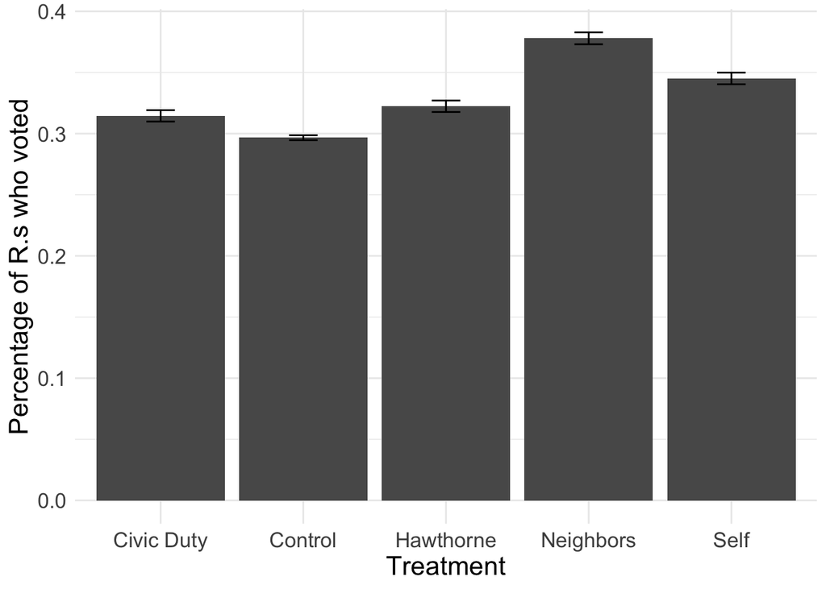

```r
GG_df2 %>%
    ggplot() +
    # x軸はTreat, y軸はVotedの平均値
    geom_bar(aes(x = Treat, y = Voted), stat = "identity") +
    # エラーバーを付ける
    geom_errorbar(aes(x = Treat, ymin = conf.low, ymax = conf.high),
                  width = 0.2) +
    # 軸ラベル
    labs(x = "Treatment", y = "Percentage of R.s who voted") +
    # シンプルなテーマに変えてみました
    theme_minimal() +
    # 文字の大きさも調整してみましょう。
    theme(text = element_text(size = 16))
```

サーベイ実験なら、サンプルサイズが大きくて数千程度なので、ここまで信頼区間が狭くはなりませんが、本実験の場合、被験者が約34万人なので、非常に狭い信頼区間が得られました。

## 回帰分析を用いた処置効果の推定

単純な処置効果の点推定のみではなく、区間推定をしてみましょう。統制群に比べて、どれほどの処置効果があり、その効果が統計的に有意な効果が否かを確認するために以下の回帰式を推定します。

$$\begin{equation}
\hat{y} = \beta_0 + \beta_1 \textrm{CivicDuty} + \beta_2 \textrm{Hawthorne} + \beta_3 \textrm{Neighbors} + \beta_4 \textrm{Self}
\end{equation}$$

CivicDuty, Hawthorneなどは各グループに属するか否かのダミー変数です。Rだとfactor型、文字型を回帰モデルに投入すると自動的にダミー化した結果を返してくれます。ただし、ベースラインはfactor型だと最も最初に指定された要素が、文字型だとアルファベット順で最も早い順番の要素になります。先ほど、`Treat`変数はfactor型にし、`Control`が最初に来るようにしましたね。だからそのまま回帰式に投入します。

回帰分析は`lm()`関数を使います。具体的には`lm(結果 ~ 処置, data = データフレーム)`です。

```r
GG_Fit1 <- lm(Voted ~ Treat, data = GG_df)

summary(GG_Fit1)
```

```
##
## Call:
## lm(formula = Voted ~ Treat, data = GG_df)
##
## Residuals:
##     Min      1Q  Median      3Q     Max
## -0.3780 -0.3145 -0.2966  0.6549  0.7034
##
## Coefficients:
##                 Estimate Std. Error t value Pr(>|t|)
## (Intercept)     0.296638   0.001061 279.525  < 2e-16 ***
## TreatCivic Duty 0.017899   0.002600   6.884 5.85e-12 ***
## TreatHawthorne  0.025736   0.002601   9.896  < 2e-16 ***
## TreatSelf       0.048513   0.002600  18.657  < 2e-16 ***
## TreatNeighbors  0.081310   0.002601  31.263  < 2e-16 ***
## ---
## Signif. codes:  0 '***' 0.001 '**' 0.01 '*' 0.05 '.' 0.1 ' ' 1
##
## Residual standard error: 0.4641 on 344079 degrees of freedom
## Multiple R-squared:  0.003394,   Adjusted R-squared:  0.003383
## F-statistic:   293 on 4 and 344079 DF,  p-value: < 2.2e-16
```

`Estimate`列が点推定値、`Std.Error`列が区間推定に用いられる標準誤差です。95%信頼区間は(点推定値 $\pm$ 1.96 $\times$ 標準誤差)です。

回帰分析から得られた推定値の可視化には{coefplot}パッケージの`coefplot()`関数が便利です。Rに慣れると{coefplot}を使わずに自分で作成した方が楽かもしれませんが、{coefplot}でも十分でしょう。

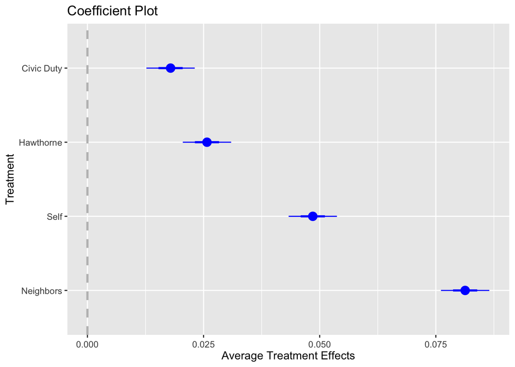

```r
# GG.Fit係数の可視化。切片なし。縦軸の順番を逆転
coefplot(GG_Fit1, intercept = FALSE, decreasing = TRUE,
         xlab = "Average Treatment Effects", # X軸の名前
         ylab = "Treatment", # Y軸の名前
         # このように縦軸名をカスタマイズすることも可能です。
         newNames = c("TreatCivic Duty" = "Civic Duty",
                      "TreatHawthorne"  = "Hawthorne",
                      "TreatNeighbors"  = "Neighbors",
                      "TreatSelf"       = "Self"),
         pointSize = 4) # ポイントの大きさ
```

これらの結果をどう評価すれば良いでしょうか。「隣人も投票しているよ」という葉書をもらった被験者は、何ももらっていない被験者よりも投票率が8.13%ポイント高いですね。統制群の投票率が29.7%で標準偏差が0.457なので、この葉書の効果は約0.178標準誤差分の効果があると言えるでしょう。効果量の指標である、Cohenの$d$だと、$d = 0.1726$であり、小さい効果量と考えられるかも知れませんが、葉書だけで投票率が8%ポイント上がることは政策的に十分に大きい効果だと判断できるでしょう。

## 重回帰分析

重回帰分析を使った分析もやってみましょう。ここでは性別（`Female`）、世帯内人数（`hh_size`）、誕生年（`yob`）、2000・2002・2004年選挙投票有無（`V2000`、`V2002`、`V2004`）を統制し、改めてATEを推定してみます。

$$\begin{array}
\hat{y} = & \beta_0 + \beta_1 \textrm{CivicDuty} + \beta_2 \textrm{Hawthorne} + \beta_3 \textrm{Neighbors} + \beta_4 \textrm{Self} + \\
& \beta_5 \textrm{Female} + \beta_6 \textrm{HouseholdSize} + \beta_7 \textrm{YearOfBrith} + \\
& \beta_8 \textrm{Voted2000} + \beta_9 \textrm{Voted2002} + \beta_{10} \textrm{Voted2004}.
\end{array}$$

やり方は先ほどとほぼ変わりません。`lm()`内のモデルを`結果 ~ 処置`から`結果 ~ 処置 + 共変量1 + 共変量2 + ...`へ変更するだけです。

```r
GG_Fit2 <- lm(Voted ~ Treat + Female + hh_size + yob +
                V2000 + V2002 + V2004, data = GG_df)

summary(GG_Fit2)
```

```
##
## Call:
## lm(formula = Voted ~ Treat + Female + hh_size + yob + V2000 +
##     V2002 + V2004, data = GG_df)
##
## Residuals:
##     Min      1Q  Median      3Q     Max
## -0.7679 -0.3344 -0.1953  0.5300  0.9359
##
## Coefficients:
##                   Estimate Std. Error t value Pr(>|t|)
## (Intercept)      5.845e+00  1.099e-01  53.202  < 2e-16 ***
## TreatCivic Duty  1.839e-02  2.504e-03   7.343 2.10e-13 ***
## TreatHawthorne   2.506e-02  2.504e-03  10.005  < 2e-16 ***
## TreatSelf        4.797e-02  2.504e-03  19.157  < 2e-16 ***
## TreatNeighbors   8.064e-02  2.504e-03  32.199  < 2e-16 ***
## Female          -5.783e-03  1.525e-03  -3.791  0.00015 ***
## hh_size          5.075e-03  1.018e-03   4.986 6.17e-07 ***
## yob             -2.913e-03  5.642e-05 -51.633  < 2e-16 ***
## V2000            9.401e-02  1.783e-03  52.722  < 2e-16 ***
## V2002            1.414e-01  1.590e-03  88.876  < 2e-16 ***
## V2004            1.578e-01  1.564e-03 100.838  < 2e-16 ***
## ---
## Signif. codes:  0 '***' 0.001 '**' 0.01 '*' 0.05 '.' 0.1 ' ' 1
##
## Residual standard error: 0.4469 on 344073 degrees of freedom
## Multiple R-squared:  0.07592,    Adjusted R-squared:  0.0759
## F-statistic:  2827 on 10 and 344073 DF,  p-value: < 2.2e-16
```

続いて、点推定値とその不確実性を可視化します。

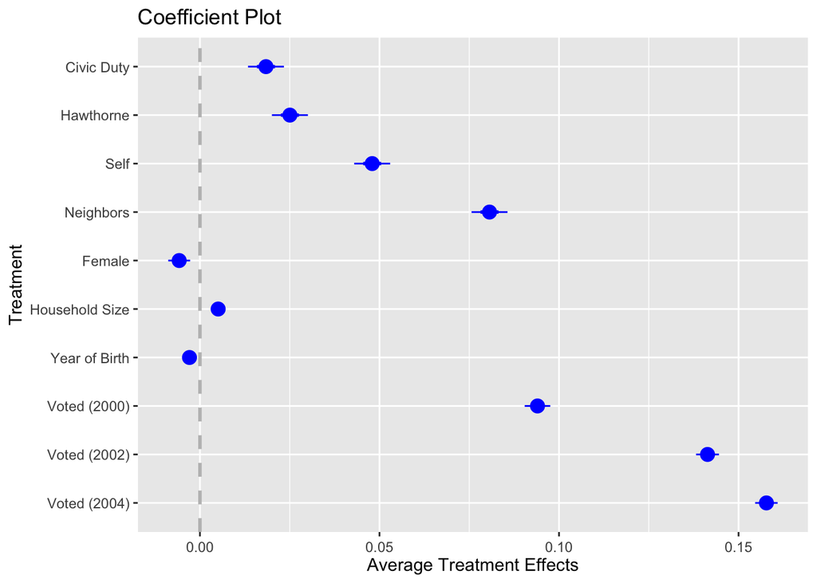

```r
# GG.Fit係数の可視化。切片なし。縦軸の順番を逆転
coefplot(GG_Fit2, intercept = FALSE, decreasing = TRUE,
         xlab = "Average Treatment Effects", # X軸の名前
         ylab = "Treatment", # Y軸の名前
         # このように縦軸名をカスタマイズすることも可能です。
         newNames = c("TreatCivic Duty" = "Civic Duty",
                      "TreatHawthorne"  = "Hawthorne",
                      "TreatNeighbors"  = "Neighbors",
                      "TreatSelf"       = "Self",
                      "hh_size"         = "Household Size",
                      "yob"             = "Year of Birth",
                      "V2000"           = "Voted (2000)",
                      "V2002"           = "Voted (2002)",
                      "V2004"           = "Voted (2004)"),
         pointSize = 4) # ポイントの大きさ
```

2つの回帰モデルから得られたパラメーターの推定値を比較してみましょう。R Markdownを使用している場合、`stargazer::stargzer()`関数が便利です。使い方は`stargazer(回帰モデル1, 回帰モデル2, ..., type = "html")`です。ただし、Markdownを使用している場合、Chunkオプションに`results = "asis"`を付けてください。また、`type = "html"`を省略した場合、$\LaTeX$形式の表が出力されます。Rコンソール上で結果を比較したいだけなら、`type = "text"`と指定します。{stargazer}パッケージには様々なオプションを提供しているので、興味のある方は[Webマニュアル](https://cran.r-project.org/web/packages/stargazer/vignettes/stargazer.pdf)を参照してください。

以下のコードには様々なオプションを付けてますが、各自1つずつ外しながら各オプションの意味を確かめてみてください。

```r
stargazer(GG_Fit1, GG_Fit2,
          # 小数点3桁まで出力、「*」を除去、数字を綺麗に揃える
          digits = 3, star.cutoffs = NA, align = TRUE,
          # サンプルサイズ、修正済みR2、F値を出力
          # ただし、F値の自由度は省略する
          keep.stat = c('n', 'adj.rsq', 'f'), df = FALSE,
          # 表のタイトル指定
          title = 'Results of Linear Regressions',
          # 応答変数名を指定
          dep.var.labels = 'Did R voted?',
          # Dependent variableをOutcome variableに変更
          dep.var.caption = 'Outcome variable',
          # Notesを削除
          omit.table.layout = "n",
          # HTML形式で出力
          type = "html")
```

**Results of Linear Regressions**

|  | Outcome variable |  |
| --- | --- | --- |
|  | Did R voted? |  |
|  | (1) | (2) |
| TreatCivic Duty | 0.018 | 0.018 |
|  | (0.003) | (0.003) |
| TreatHawthorne | 0.026 | 0.025 |
|  | (0.003) | (0.003) |
| TreatSelf | 0.049 | 0.048 |
|  | (0.003) | (0.003) |
| TreatNeighbors | 0.081 | 0.081 |
|  | (0.003) | (0.003) |
| Female |  | -0.006 |
|  |  | (0.002) |
| hh_size |  | 0.005 |
|  |  | (0.001) |
| yob |  | -0.003 |
|  |  | (0.0001) |
| V2000 |  | 0.094 |
|  |  | (0.002) |
| V2002 |  | 0.141 |
|  |  | (0.002) |
| V2004 |  | 0.158 |
|  |  | (0.002) |
| Constant | 0.297 | 5.845 |
|  | (0.001) | (0.110) |
| Observations | 344,084 | 344,084 |
| Adjusted R<sup>2</sup> | 0.003 | 0.076 |
| F Statistic | 292.976 | 2,826.942 |

処置がランダム化されているため、結果に大きな変化はありません。

{modelsummary}を使っても同じようなことができます。注意点としては複数のモデルを`modelsummary()`に渡す際、list型としてまとめて渡す必要がある点です。`modelsummary()`関数の詳細な使い方はRコンソール上で`?modelsummary`を入力し、参照してください。

```r
library(modelsummary)
modelsummary(list(GG_Fit1, GG_Fit2),
             coef_rename = c("TreatCivic Duty" = "Civic Duty",
                             "TreatHawthorne"  = "Hawthorne",
                             "TreatNeighbors"  = "Neighbors",
                             "TreatSelf"       = "Self",
                             "hh_size"         = "Household Size",
                             "yob"             = "Year of Birth",
                             "V2000"           = "Voted (2000)",
                             "V2002"           = "Voted (2002)",
                             "V2004"           = "Voted (2004)"),
             gof_omit = "AIC|BIC|Log.Lik")
```

|  | Model 1 | Model 2 |
| --- | --- | --- |
| (Intercept) | 0.297 | 5.845 |
|  | (0.001) | (0.110) |
| Civic Duty | 0.018 | 0.018 |
|  | (0.003) | (0.003) |
| Hawthorne | 0.026 | 0.025 |
|  | (0.003) | (0.003) |
| Self | 0.049 | 0.048 |
|  | (0.003) | (0.003) |
| Neighbors | 0.081 | 0.081 |
|  | (0.003) | (0.003) |
| Female |  | -0.006 |
|  |  | (0.002) |
| Household Size |  | 0.005 |
|  |  | (0.001) |
| Year of Birth |  | -0.003 |
|  |  | (0.000) |
| Voted (2000) |  | 0.094 |
|  |  | (0.002) |
| Voted (2002) |  | 0.141 |
|  |  | (0.002) |
| Voted (2004) |  | 0.158 |
|  |  | (0.002) |
| Num.Obs. | 344084 | 344084 |
| R2 | 0.003 | 0.076 |
| R2 Adj. | 0.003 | 0.076 |
| F | 292.976 | 2826.942 |